# Optimizing LDA Topic Model for Interpretability

With so many online reviews across many social media websites, it is hard for companies to keep track of their online reputation. Businesses can benefit immensely if they can understand general trends of what their customers are talking about online. A common method to quickly understand trends in topics being discussed in a corpus of text is Latent Dirichlet Allocation (LDA).

**Latent Dirichlet Allocation:**

LDA assumes each document consists of a combination of topics, and each topic consists of a combination of words. It then approximates probability distributions of topics in a given document and of words in a given topic. For example:

- Document 1: Topic1 = 0.33, Topic2 = 0.33, Topic3 = 0.33
- Topic 1: Product = 0.39, Payment = 0.32, Store = 0.29

LDA is a type of Bayesian Inference Model. It assumes that the topics are generated before documents, and infer topics that could have generated the a corupus of documents (a review = a document). The generative process for each document w in corpus D is as belows:

1. Choose $ N \mathtt{\sim} Poisson(E) $ to represent the document length distributions (other distributions can be used)
2. Choose $\theta \mathtt{\sim} Dir(\alpha) $ as a multinomial distribution to represent the distribution of K topics over a document
   - For example, a document may consist of 1/3 product and 2/3 store
3. For each of N words $ w_{n}$:
   - Choose a topic from the distribution $ z_{n} \mathtt{\sim} Multinomial(\theta)$
   - Choose a word $ w_{n} $ from $ p(w_{n}|z_{n},\beta) $, a multinomial probability conditioned on topic $ Z_{n} $
     - E.g. if select food topic, generate word 'broccoli' with 30\% probability and bananas with 15\% probability
     - Generate document - e.g. if length is 5, then generate set of 5 words with probability distribution across words for a given topic such as "broccoli eat food animal meat"
4. Find set of topics that are most likely to have generated the collection of documents

**Learning:**

1. Given a set of documents, go through each document, and randomly assign each word in the document to one of the K topics
   - This gives random assignment of topic representations of all the documents and word distributions of all the topics
   - Because this is random, it will not be good
2. To improve, for each document D, go through each word in D:
   - For each topic t, compute:
     - $ p(topic_t | document_d)$ = proportion of words in document d that are assigned to topic t
     - $ p(word_w | topic_t)$ = proportion of assignments to topic t over all documents that come from word w (how many w in all documents' words are assigned to t)
     - Reassign with a new topic, where we choose topic t with probability $p(topic_t|document_d)*p(word_w|topic_t)$, which is essentially the probability that topic t generated word w
   - Update assignment of current word in the loop assuming topic assignment distributions for the rest of the corpus are correct
3. Keep iterating until assignments reach a steady state
   - Use these assignments to estimate topic mixtures of each document (\% words assigned to each topic within that document) and word associated to each topic (\% of words assigned to each topic overall)

The dimensionality K of Dirichlet distribution (aka # of topics) is assumed to be known and fixed.

We will try LDA and explore techniques to optimize interpretability using Amazon Office Product reviews. Dataset can be found here: http://jmcauley.ucsd.edu/data/amazon/

```python
import warnings
warnings.filterwarnings("ignore", category=DeprecationWarning)
```

```python
import spacy
import nltk
import re
import string
import pandas as pd
import numpy as np
from stop_word_list import *
from clean_text import *
import gensim
from gensim import corpora
import pyLDAvis.gensim
import matplotlib.pyplot as plt
import json
%matplotlib inline
```

## Load and Clean Text

```python
# Load the data
data=[]
for line in open('reviews_Office_Products_5.json', 'r'):
    data.append(json.loads(line))
```

```python
df = pd.DataFrame(data)
```

```python
df.head()
```

|  | reviewerID | asin | reviewerName | helpful | reviewText | overall | summary | unixReviewTime | reviewTime |
| --- | --- | --- | --- | --- | --- | --- | --- | --- | --- |
| 0 | A32T2H8150OJLU | B00000JBLH | ARH | [3, 4] | I bought my first HP12C in about 1984 or so, a... | 5.0 | A solid performer, and long time friend | 1094169600 | 09 3, 2004 |
| 1 | A3MAFS04ZABRGO | B00000JBLH | Let it Be "Alan" | [7, 9] | WHY THIS BELATED REVIEW? I feel very obliged t... | 5.0 | Price of GOLD is up, so don't bury the golden ... | 1197676800 | 12 15, 2007 |
| 2 | A1F1A0QQP2XVH5 | B00000JBLH | Mark B | [3, 3] | I have an HP 48GX that has been kicking for mo... | 2.0 | Good functionality, but not durable like old HPs | 1293840000 | 01 1, 2011 |
| 3 | A49R5DBXXQDE5 | B00000JBLH | R. D Johnson | [7, 8] | I've started doing more finance stuff recently... | 5.0 | One of the last of an almost extinct species | 1145404800 | 04 19, 2006 |
| 4 | A2XRMQA6PJ5ZJ8 | B00000JBLH | Roger J. Buffington | [0, 0] | For simple calculations and discounted cash fl... | 5.0 | Still the best | 1375574400 | 08 4, 2013 |

```python
# Extract only reviews text
reviews = pd.DataFrame(df.reviewText)
```

```python
clean_reviews = clean_all(reviews, 'reviewText')
```

```python
clean_reviews.head()
```

|  | reviewText |
| --- | --- |
| 0 | b i buy PRON first hp c in about or so and PRO... |
| 1 | b why this belate review i feel very obliged t... |
| 2 | b i have an hp gx that have be kick for more t... |
| 3 | b i ve start do more finance stuff recently an... |
| 4 | b for simple calculation and discount cash flo... |

## Form Bigrams & Trigrams

We want to identify bigrams and trigrams so we can concatenate them and consider them as one word. Bigrams are phrases containing 2 words e.g. ‘social media’, where ‘social’ and ‘media’ are more likely to co-occur rather than appear separately. Likewise, trigrams are phrases containing 3 words that more likely co-occur e.g. ‘Proctor and Gamble’. We use Pointwise Mutual Information score to identify significant bigrams and trigrams to concatenate. We also filter bigrams or trigrams with the filter (noun/adj, noun), (noun/adj,all types,noun/adj) because these are common structures pointing out noun-type n-grams. This helps the LDA model better cluster topics.

```python
bigram_measures = nltk.collocations.BigramAssocMeasures()
finder = nltk.collocations.BigramCollocationFinder.from_documents([comment.split() for comment in clean_reviews.reviewText])
# Filter only those that occur at least 50 times
finder.apply_freq_filter(50)
bigram_scores = finder.score_ngrams(bigram_measures.pmi)
```

```python
trigram_measures = nltk.collocations.TrigramAssocMeasures()
finder = nltk.collocations.TrigramCollocationFinder.from_documents([comment.split() for comment in clean_reviews.reviewText])
# Filter only those that occur at least 50 times
finder.apply_freq_filter(50)
trigram_scores = finder.score_ngrams(trigram_measures.pmi)
```

```python
bigram_pmi = pd.DataFrame(bigram_scores)
bigram_pmi.columns = ['bigram', 'pmi']
bigram_pmi.sort_values(by='pmi', axis = 0, ascending = False, inplace = True)
```

```python
trigram_pmi = pd.DataFrame(trigram_scores)
trigram_pmi.columns = ['trigram', 'pmi']
trigram_pmi.sort_values(by='pmi', axis = 0, ascending = False, inplace = True)
```

```python
# Filter for bigrams with only noun-type structures
def bigram_filter(bigram):
    tag = nltk.pos_tag(bigram)
    if tag[0][1] not in ['JJ', 'NN'] and tag[1][1] not in ['NN']:
        return False
    if bigram[0] in stop_word_list or bigram[1] in stop_word_list:
        return False
    if 'n' in bigram or 't' in bigram:
        return False
    if 'PRON' in bigram:
        return False
    return True
```

```python
# Filter for trigrams with only noun-type structures
def trigram_filter(trigram):
    tag = nltk.pos_tag(trigram)
    if tag[0][1] not in ['JJ', 'NN'] and tag[1][1] not in ['JJ','NN']:
        return False
    if trigram[0] in stop_word_list or trigram[-1] in stop_word_list or trigram[1] in stop_word_list:
        return False
    if 'n' in trigram or 't' in trigram:
         return False
    if 'PRON' in trigram:
        return False
    return True
```

```python
# Can set pmi threshold to whatever makes sense - eyeball through and select threshold where n-grams stop making sense
# choose top 500 ngrams in this case ranked by PMI that have noun like structures
filtered_bigram = bigram_pmi[bigram_pmi.apply(lambda bigram:\
                                              bigram_filter(bigram['bigram'])\
                                              and bigram.pmi > 5, axis = 1)][:500]

filtered_trigram = trigram_pmi[trigram_pmi.apply(lambda trigram: \
                                                 trigram_filter(trigram['trigram'])\
                                                 and trigram.pmi > 5, axis = 1)][:500]


bigrams = [' '.join(x) for x in filtered_bigram.bigram.values if len(x[0]) > 2 or len(x[1]) > 2]
trigrams = [' '.join(x) for x in filtered_trigram.trigram.values if len(x[0]) > 2 or len(x[1]) > 2 and len(x[2]) > 2]
```

```python
# examples of bigrams
bigrams[:10]
```

```
['hewlett packard',
 'wal mart',
 'akt le',
 'http www',
 'carpal tunnel',
 'snow leopard',
 'allen wrench',
 'trapper keeper',
 'stanley bostitch',
 'recommended cfh']
```

```python
# examples of trigrams
trigrams[:10]
```

```
['http www amazon',
 'epson labelworks lw',
 'www amazon com',
 'cyan magenta yellow',
 'thermal laminating pouch',
 'adhesive dot roller',
 'wilson jones heavy',
 'black cyan magenta',
 'automatic document feeder',
 'amazon vine program']
```

```python
# Concatenate n-grams
def replace_ngram(x):
    for gram in trigrams:
        x = x.replace(gram, '_'.join(gram.split()))
    for gram in bigrams:
        x = x.replace(gram, '_'.join(gram.split()))
    return x
```

```python
reviews_w_ngrams = clean_reviews.copy()
```

```python
reviews_w_ngrams.reviewText = reviews_w_ngrams.reviewText.map(lambda x: replace_ngram(x))
```

```python
# tokenize reviews + remove stop words + remove names + remove words with less than 2 characters
reviews_w_ngrams = reviews_w_ngrams.reviewText.map(lambda x: [word for word in x.split()\
                                                 if word not in stop_word_list\
                                                              and word not in english_names\
                                                              and len(word) > 2])
```

```python
reviews_w_ngrams.head()
```

```
0    [buy, PRON, PRON, serve, PRON, faithfully, los...
1    [belate, review, feel, obliged, share, PRON, v...
2    [kick, year, year, old, flawless, month, numbe...
3    [start, finance, stuff, recently, look, good, ...
4    [simple, calculation, discount, cash, flow, go...
Name: reviewText, dtype: object
```

## Filter for only nouns

Nouns are most likely indicators of a topic. For example, for the sentence ‘The store is nice’, we know the sentence is talking about ‘store’. The other words in the sentence provide more context and explanation about the topic (‘store’) itself. Therefore, filtering for the noun cleans the text for words that are more interpretable in the topic model.

```python
# Filter for only nouns
def noun_only(x):
    pos_comment = nltk.pos_tag(x)
    filtered = [word[0] for word in pos_comment if word[1] in ['NN']]
    # to filter both noun and verbs
    #filtered = [word[0] for word in pos_comment if word[1] in ['NN','VB', 'VBD', 'VBG', 'VBN', 'VBZ']]
    return filtered
```

```python
final_reviews = reviews_w_ngrams.map(noun_only)
```

## LDA Model

```python
dictionary = corpora.Dictionary(final_reviews)
```

```python
doc_term_matrix = [dictionary.doc2bow(doc) for doc in final_reviews]
```

### Optimize # of k topics

LDA requires that we specify the number of topics that exists in a corpus of text. There are several common measures that can be optimized, such as predictive likelihood, perplexity, and coherence. Much literature has indicated that maximizing coherence, particularly a measure named Cv (https://svn.aksw.org/papers/2015/WSDM_Topic_Evaluation/public.pdf), leads to better human interpretability. This measure assesses the interpretability of topics given the set of words in generated topics. Therefore, we will optimize this measure.

Since eval_only calculates perplexity metric, we can set it to None to save time, as we will use a different metric called Cv.

Try 5-25 topics...

```python
coherence = []
for k in range(5,25):
    print('Round: '+str(k))
    Lda = gensim.models.ldamodel.LdaModel
    ldamodel = Lda(doc_term_matrix, num_topics=k, id2word = dictionary, passes=40,\
                   iterations=200, chunksize = 10000, eval_every = None)

    cm = gensim.models.coherencemodel.CoherenceModel(model=ldamodel, texts=final_reviews,\
                                                     dictionary=dictionary, coherence='c_v')
    coherence.append((k,cm.get_coherence()))
```

```
Round: 5
Round: 6
Round: 7
Round: 8
Round: 9
Round: 10
Round: 11
Round: 12
Round: 13
Round: 14
Round: 15
Round: 16
Round: 17
Round: 18
Round: 19
Round: 20
Round: 21
Round: 22
Round: 23
Round: 24
```

```python
x_val = [x[0] for x in coherence]
y_val = [x[1] for x in coherence]
```

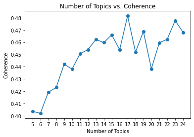

```python
plt.plot(x_val,y_val)
plt.scatter(x_val,y_val)
plt.title('Number of Topics vs. Coherence')
plt.xlabel('Number of Topics')
plt.ylabel('Coherence')
plt.xticks(x_val)
plt.show()
```

The improvement stops to significantly improve after 15 topics. It is not always where the highest Cv is, so we can try a couple to see which has the best result. We'll try 15 and 23 here. Adding topics can help reveal further sub topics. Nonetheless, if the same words start to appear across multiple topics, the number of topics is too high.

```python
Lda = gensim.models.ldamodel.LdaModel
ldamodel = Lda(doc_term_matrix, num_topics=15, id2word = dictionary, passes=40,\
               iterations=200,  chunksize = 10000, eval_every = None, random_state=0)
```

```python
Lda2 = gensim.models.ldamodel.LdaModel
ldamodel2 = Lda2(doc_term_matrix, num_topics=23, id2word = dictionary, passes=40,\
               iterations=200,  chunksize = 10000, eval_every = None, random_state=0)
```

Other explanation of parameters: https://radimrehurek.com/gensim/models/ldamodel.html

```python
# To show initial topics
ldamodel.show_topics(15, num_words=10, formatted=False)
```

```
[(0,
  [('note', 0.05554076),
   ('color', 0.051286757),
   ('use', 0.048626028),
   ('post', 0.04068646),
   ('marker', 0.033643845),
   ('board', 0.028574942),
   ('work', 0.0190825),
   ('magnet', 0.01893561),
   ('pad', 0.015846577),
   ('stick', 0.01408235)]),
 (1,
  [('folder', 0.08729111),
   ('tab', 0.085292436),
   ('chair', 0.06593559),
   ('file', 0.06276117),
   ('use', 0.02441812),
   ('file_folder', 0.022120677),
   ('office', 0.021025151),
   ('color', 0.018232403),
   ('seat', 0.014802855),
   ('product', 0.013404625)]),
 (2,
  [('binder', 0.09963777),
   ('pocket', 0.045993555),
   ('paper', 0.043687668),
   ('cover', 0.03973441),
   ('use', 0.028761666),
   ('notebook', 0.02356954),
   ('plastic', 0.019488329),
   ('divider', 0.0129221305),
   ('sheet', 0.010436761),
   ('look', 0.009696761)]),
 (3,
  [('pencil', 0.046214968),
   ('use', 0.039241314),
   ('work', 0.017876107),
   ('hand', 0.017292611),
   ('point', 0.015187497),
   ('mouse', 0.012842767),
```

[output cut: 110 more lines]

```
   ('scale', 0.015635148),
   ('time', 0.014621188),
   ('service', 0.014241095),
   ('base', 0.014212798)]),
 (14,
  [('use', 0.043373954),
   ('thing', 0.02428259),
   ('book', 0.023880767),
   ('work', 0.022635672),
   ('year', 0.020149278),
   ('shredder', 0.019987088),
   ('time', 0.018705543),
   ('school', 0.017381074),
   ('day', 0.013657781),
   ('home', 0.012003456)])]
```

```python
# To show initial topics
ldamodel2.show_topics(23, num_words=10, formatted=False)
```

```
[(0,
  [('color', 0.13042007),
   ('use', 0.04939971),
   ('marker', 0.049138594),
   ('ink', 0.045652367),
   ('write', 0.025547048),
   ('tip', 0.02120447),
   ('work', 0.01799116),
   ('sharpie', 0.015334195),
   ('line', 0.013950256),
   ('cap', 0.01391556)]),
 (1,
  [('tab', 0.12561414),
   ('folder', 0.105585515),
   ('file', 0.07379385),
   ('use', 0.044929538),
   ('file_folder', 0.028123518),
   ('color', 0.027827552),
   ('document', 0.018135134),
   ('divider', 0.017267503),
   ('product', 0.014797443),
   ('work', 0.012500131)]),
 (2,
  [('binder', 0.13120762),
   ('pocket', 0.060566276),
   ('cover', 0.051677737),
   ('paper', 0.03549023),
   ('notebook', 0.029100694),
   ('use', 0.024918718),
   ('plastic', 0.022741886),
   ('spine', 0.01185665),
   ('look', 0.010828309),
   ('hold', 0.0097193085)]),
 (3,
  [('scanner', 0.037928365),
   ('software', 0.032020744),
   ('use', 0.02661672),
   ('device', 0.019739488),
   ('work', 0.018324248),
   ('document', 0.01643745),
```

[output cut: 198 more lines]

```
   ('mail', 0.01749215),
   ('design', 0.017376171),
   ('place', 0.017036516),
   ('item', 0.016385237)]),
 (22,
  [('desk', 0.06657937),
   ('chair', 0.04610483),
   ('monitor', 0.023994518),
   ('sit', 0.020361725),
   ('arm', 0.01725616),
   ('look', 0.0159833),
   ('use', 0.015491127),
   ('work', 0.015354036),
   ('office', 0.015131725),
   ('foot', 0.01365214)])]
```

23 topics yielded clearer results, so we'll go with this...

## Relevancy

Sometimes, words that are ranked as top words for a given topic may be ranked high because they are globally frequent across text in a corpus. Relevancy score helps to prioritize terms that belong more exclusively to a given topic. This can increase interpretability even more. The relevance of term w to topic k is defined as:

$ r(w,k| \lambda) = \lambda log(\phi_{kw}) +(1-\lambda)log(\frac{\phi_{kw}}{p_{kw}}) $

Paper behind this tool: https://nlp.stanford.edu/events/illvi2014/papers/sievert-illvi2014.pdf

```python
topic_data =  pyLDAvis.gensim.prepare(ldamodel2, doc_term_matrix, dictionary, mds = 'pcoa')
pyLDAvis.display(topic_data)
```

[interactive chart not shown]

To extract the words for a given lambda:

```python
all_topics = {}
num_terms = 10 # Adjust number of words to represent each topic
lambd = 0.6 # Adjust this accordingly based on tuning above
for i in range(1,24): #Adjust this to reflect number of topics chosen for final LDA model
    topic = topic_data.topic_info[topic_data.topic_info.Category == 'Topic'+str(i)].copy()
    topic['relevance'] = topic['loglift']*(1-lambd)+topic['logprob']*lambd
    all_topics['Topic '+str(i)] = topic.sort_values(by='relevance', ascending=False).Term[:num_terms].values
```

```python
pd.DataFrame(all_topics).T
```

|  | 0 | 1 | 2 | 3 | 4 | 5 | 6 | 7 | 8 | 9 |
| --- | --- | --- | --- | --- | --- | --- | --- | --- | --- | --- |
| Topic 1 | printer | print | photo | epson | cartridge | ink | canon | color | wireless | fax |
| Topic 2 | scanner | software | device | image | app | document | tablet | program | option | ipad |
| Topic 3 | price | cost | ink | buy | amazon | brand | purchase | pay | cartridge | quality |
| Topic 4 | school | use | year | home | child | day | thing | kid | organizer | son |
| Topic 5 | stapler | laminator | staple | laminate | swingline | machine | use | heat | sheet | lamination |
| Topic 6 | tape | dispenser | roll | scotch | package | use | wrap | strip | packing_tape | packaging |
| Topic 7 | label | avery | template | print | peel | address | use | ticket | product | sticker |
| Topic 8 | color | marker | write | ink | tip | sharpie | cap | erase | blue | skin |
| Topic 9 | board | magnet | wall | hang | fridge | frame | door | refrigerator | mount | surface |
| Topic 10 | desk | chair | monitor | arm | sit | foot | seat | password | position | leg |
| Topic 11 | binder | pocket | cover | notebook | spine | plastic | ring | paper | divider | hinge |
| Topic 12 | paper | sheet | envelope | airprint | security | control_panel | card_stock | pastel | ream | cardstock |
| Topic 13 | phone | shredder | wifi | handset | sound | service | number | unit | cell_phone | message |
| Topic 14 | note | post | book | sticky_note | mark | pad | stick | flag | use | cloud |
| Topic 15 | box | storage | item | cardboard | store | banker_box | pack | handle | size | bubble_wrap |
| Topic 16 | surface | mouse | pad | wrist | glue | mouse_pad | keyboard | bottle | rest | use |
| Topic 17 | pencil | sharpener | scale | lead | pencil_sharpener | cup | barrel | mechanical_pencil | point | clip |
| Topic 18 | line | list | section | cut | scissor | speaker | cutter | activity | trimmer | blade |
| Topic 19 | tab | folder | file | file_folder | divider | paperwork | filing | tax | file_cabinet | use |
| Topic 20 | card | iphone | gift | fun | picture | cute | love | art | business_card | shirt |
| Topic 21 | display | battery | button | calculator | power | function | key | press | ounce | light |
| Topic 22 | holder | letter | drawer | mail | product | hanging_folder | filing_cabinet | slot | stamp | monitor_arm |
| Topic 23 | label_maker | label | dymo | font | labeler | symbol | comb | border | brother | versatile |

We can see here that most topics are quite clear. In this case, they are clustered into the different products being talked about in the reviews. Some clear topics are:

- Printer products
- Scanner proudcts
- Printer Ink, pricing/quality
- School stationary
- Lamination
- Packing tape
- Mailing labels
- Markers
- Magnetic boards
- Workstation
- Binder
- Paper products
- Phone
- Post-its
- Storage/packing materials
- Mouse/keyboard
- Pencil
- Cutting
- File Organizer
- Business card
- Calculator
- Mailing materials
- Label maker

Other models:

- Non-negative matrix factorization (NMF): Less computationally expensive, but assumes fixed probability vectors of multinomials across documents, while LDA allows this to vary. If we believe the topic probabilities should remain fixed for each document, or in small data setting where additional variability from priors is too much, NMF might be better.
- Latent semantic indexing: a variant of PCA/SVD. Again, much faster, but generally less accurate. Similar to NMF, but different loss constraint.
- Hierarchical Dirchlet Process: Uses posterior inference to determine the number of topics for you

https://www.cs.cmu.edu/~epxing/Class/10708-15/slides/LDA_SC.pdf  
https://en.wikipedia.org/wiki/Hierarchical_Dirichlet_process